# Modelo de Clasificación Binaria para la Predicción de Bancarrota Empresarial a partir de Estados Financieros: Dataset Taiwan Economic Journal

Análisis de Solvencia Corporativa y Riesgo Financiero con Machine Learning

*Laura Rivera · Natalý Cárdenas*

`sriveral@uninorte.edu.co` · `nizaquita@uninorte.edu.co`

Departamento de Matemáticas, Física y Ciencia de Datos, Universidad del Norte, Barranquilla, Colombia

**Asignatura:** Visualización de Datos

**Metodología:** EDA · Feature Engineering · Modelos de Clasificación

# 1 Introducción

Predecir con anticipación el riesgo de bancarrota de una empresa es un problema de alto impacto: permite a inversionistas, entidades financieras y a la propia gerencia tomar decisiones oportunas para prevenir o mitigar pérdidas, en lugar de reaccionar cuando la quiebra ya es inminente. Contar con un modelo que identifique señales tempranas de riesgo financiero, a partir de indicadores contables que las empresas ya reportan, aporta valor tanto para el análisis de crédito como para la supervisión financiera.

Para este proyecto se utiliza el dataset del **Taiwan Economic Journal**, que reúne información financiera de **6.819 empresas** que cotizaron en la Bolsa de Taiwán entre 1999 y 2009. Cada empresa está descrita por **95 ratios financieros** (rentabilidad, liquidez, endeudamiento, eficiencia operativa, entre otros) y por una variable objetivo binaria que indica si la empresa terminó en bancarrota o no.

## 1.1 Marco Teórico

**Riesgo de insolvencia / quiebra empresarial:** es la probabilidad de que una empresa no pueda cumplir con sus obligaciones financieras (pago de deudas, proveedores, nómina, etc.) y, como consecuencia, entre en un proceso legal de bancarrota. Este riesgo suele acumularse de forma progresiva y deja huellas medibles en los estados financieros de la empresa mucho antes de que la quiebra sea formal.

**Ratios financieros:** son relaciones entre dos cifras del estado financiero de una empresa (por ejemplo, utilidad neta entre activos totales) que permiten comparar el desempeño de empresas de tamaños distintos en una misma escala, y que resumen aspectos como rentabilidad, liquidez, endeudamiento y eficiencia.

**Modelos de clasificación:** dado que el problema consiste en distinguir entre dos categorías (empresa que quiebra vs. empresa que no quiebra) a partir de los ratios financieros, es natural abordarlo como un problema de **clasificación binaria supervisada**. Un modelo de este tipo aprende, a partir de datos históricos etiquetados, los patrones en los ratios que están asociados con la quiebra, para luego poder estimar el riesgo de empresas nuevas.

## 1.2 Objetivos

### 1.2.1 Objetivo general

Desarrollar un dashboard con un modelo predictivo de riesgo de bancarrota empresarial, que permita explorar los datos financieros de las empresas y estimar su nivel de riesgo.

### 1.2.2 Objetivos específicos

- Realizar un análisis exploratorio de datos (EDA) que permita entender la calidad, distribución y relaciones entre los ratios financieros del dataset.
- Tratar el desbalance de clases presente en la variable objetivo antes de entrenar los modelos.
- Entrenar y comparar distintos modelos de clasificación para identificar el que mejor predice el riesgo de bancarrota.
- Construir un dashboard interactivo que integre el EDA y, en etapas posteriores, el modelo predictivo.

## 1.3 Metodología

El proyecto sigue un flujo de trabajo secuencial: primero un **análisis exploratorio de datos (EDA)**, que permite entender la estructura, calidad y relaciones entre las variables; luego un **preprocesamiento**, donde se tratan los problemas identificados en el EDA (variables redundantes, desbalance de clases, escalas distintas, entre otros); después el **modelado**, en el que se entrenan y comparan distintos algoritmos de clasificación; y finalmente la construcción del **dashboard**, que integra los resultados de las etapas anteriores en una herramienta interactiva.

## 1.4 Resumen del Proyecto

Este proyecto desarrolla un análisis integral del riesgo de insolvencia empresarial a partir de indicadores financieros corporativos. En primer lugar, se realiza un análisis exploratorio de datos (EDA) para comprender la estructura del conjunto de datos, estudiar la distribución de las variables, identificar valores faltantes, detectar posibles sesgos y examinar las relaciones entre los indicadores de solvencia y la quiebra empresarial.

## 1.5 Estructura del Análisis

1. Análisis Exploratorio (EDA)

   Evaluación de distribuciones, tratamiento de valores faltantes, detección de sesgo y análisis de correlación entre variables financieras.
2. Modelado y Predicción

   Entrenamiento de algoritmos supervisados, optimización de hiperparámetros y evaluación de métricas orientadas a la detección de riesgo (Recall / ROC-AUC).

> **See also**

> Enlaces de interés **Conjunto de datos**
> - [UCI Machine Learning Repository — Taiwanese Bankruptcy Prediction](https://archive.ics.uci.edu/dataset/572/taiwanese+bankruptcy+prediction)
> - [Kaggle — Company Bankruptcy Prediction](https://www.kaggle.com/datasets/fedesoriano/company-bankruptcy-prediction)

> **Repositorio del proyecto**
> - [GitHub](https://github.com/lauraformore/BancarrotaEmpresarial_VIZ)

# 2 Análisis Exploratorio de Datos (EDA) - Company Bankruptcy Prediction (Taiwan)

## 2.1 CONTEXTO

**Objetivo:** Realizar un análisis exploratorio de datos (EDA) sobre el conjunto de información financiera de empresas taiwanesas con el propósito de comprender su estructura, calidad, distribución y relaciones entre variables, y así preparar una base sólida para el desarrollo de un modelo predictivo de quiebra empresarial.

> Primero se separan los datos en `train` y `test`, y **todo el análisis exploratorio se hace únicamente sobre `train`**. El conjunto `test` se reserva y no se toca hasta la evaluación final del modelo, para evitar *data leakage* (que información del conjunto de prueba influya en decisiones tomadas antes de entrenar el modelo).

### 2.1.1 ¿Qué es un “ratio” financiero?

Este concepto financiero es primordial para entender el resto del note. Se refiere a una relación entre dos cifras del estado financiero de una empresa (por ejemplo, utilidad entre activos) que permite comparar empresas de tamaños distintos en una misma escala. El dataset tiene 95 ratios de este tipo, todos ya calculados.

## 2.2 ETL (extracción, transformación y carga)

Carguemos los datos y verifiquemos su calidad.

### 2.2.1 Importación de librerias y configuración visual

```r
# Importar librerías necesarias
# Si te falta algún paquete, instálalo una vez con:
# install.packages(c("tidyverse", "e1071", "scales", "knitr", "kableExtra",
#                    "patchwork", "car", "base64enc"))
library(tidyverse)
library(e1071)        # skewness(), kurtosis()
library(scales)       # comma(), percent()
library(knitr)        # kable()
library(kableExtra)   # tablas con estilo y scroll
library(patchwork)    # combinar varios ggplot
library(base64enc)    # embeber imágenes en el HTML

RANDOM_STATE <- 42
set.seed(RANDOM_STATE)

# -----------------------------------------------------------------------
# CONFIGURACIÓN VISUAL GLOBAL (se define UNA sola vez y se reutiliza en
# todo el documento, en vez de repetirse en cada chunk de gráficos)
# -----------------------------------------------------------------------
# Paleta de colores del proyecto
PALETTE <- list(
  downriver  = "#032451",  # Azul oscuro -> Clase 0 / No quiebra / títulos
  stone_blue = "#3D4D65",  # Ejes y texto secundario
  poinciana  = "#CE2F25",  # Rojo -> Clase 1 / Quiebra / alertas
  flame      = "#F94C1F",  # Acentuación (líneas KDE, etc.)
  tangerine  = "#FE8005",  # Acento secundario
  tagao      = "#FBBA76",  # Tono cálido de apoyo
  bg_card    = "#FDF9F5"   # Fondo de las tarjetas de interpretación
)

TARGET_COLORS <- c("0" = PALETTE$downriver, "1" = PALETTE$poinciana)
TARGET_LABELS <- c("0" = "No quebradas (0)", "1" = "Quebradas (1)")
CMAP_CORR <- c(PALETTE$downriver, "#F4F8FB", PALETTE$poinciana)

tema_eda <- theme_minimal(base_size = 12) +
  theme(
    plot.title       = element_text(face = "bold", size = 13, color = PALETTE$downriver),
    axis.title       = element_text(size = 10, face = "bold", color = PALETTE$stone_blue),
    axis.text        = element_text(color = PALETTE$stone_blue),
    panel.grid.minor = element_blank(),
    legend.position  = "none"
  )
theme_set(tema_eda)

# -----------------------------------------------------------------------
# FUNCIONES REUTILIZABLES (evitan repetir el mismo bloque de HTML/estilo
# de tabla en cada sección del documento)
# -----------------------------------------------------------------------
fmt_int <- function(x) formatC(x, format = "f", digits = 0, big.mark = ",")

tarjeta_interpretacion <- function(titulo, cuerpo_html, color_borde = NULL) {
  # Tarjeta HTML con el estilo visual del proyecto para interpretaciones.
  if (is.null(color_borde)) color_borde <- PALETTE$poinciana
  cat(paste0(
    '<div style="background-color:', PALETTE$bg_card, ';border-left:5px solid ', color_borde,
    ';border-radius:6px;padding:14px 18px;margin:10px 0 30px 0;box-shadow:0 2px 8px rgba(3,36,81,0.05);',
    'font-family:\'Segoe UI\',-apple-system,BlinkMacSystemFont,Roboto,sans-serif;">',
    '<div style="color:', PALETTE$downriver, ';margin:0 0 8px 0;font-size:14px;font-weight:700;',
    'text-transform:uppercase;letter-spacing:.5px;">', titulo, '</div>',
    '<p style="margin:0;color:', PALETTE$stone_blue, ';font-size:13.5px;line-height:1.6;">',
    gsub("\n", " ", cuerpo_html), '</p></div>\n\n'
  ))
}

aplicar_formatos <- function(df, formatos) {
  for (col in names(formatos)) {
    f <- formatos[[col]]
    df[[col]] <- if (is.function(f)) f(df[[col]]) else sprintf(f, df[[col]])
  }
  df
}

tabla_html <- function(df, formatos = NULL, alto_px = NULL) {
  if (!is.null(formatos)) df <- aplicar_formatos(df, formatos)
  k <- kable(df, format = "html", align = "l") %>%
    kable_styling(bootstrap_options = c("condensed", "hover"), full_width = FALSE,
                  position = "left", font_size = 12) %>%
    row_spec(0, bold = TRUE, color = "white", background = PALETTE$downriver)
  if (!is.null(alto_px)) k <- scroll_box(k, height = paste0(alto_px, "px"))
  as.character(k)
}

tabla_estilo <- function(df, formatos = NULL, titulo = NULL) {
  # Tabla con el estilo visual del proyecto (para tablas cortas, sin scroll).
  if (!is.null(titulo)) {
    cat(sprintf("<div style='color:%s;font-family:Segoe UI, sans-serif;margin-bottom:6px;font-weight:700;font-size:16px;'>%s</div>\n\n",
                PALETTE$downriver, titulo))
  }
  cat(tabla_html(df, formatos), "\n\n")
}

tabla_estilo_scroll <- function(df, formatos = NULL, titulo = NULL, alto_px = 420) {
  # Igual que tabla_estilo, pero dentro de un contenedor con scroll vertical.
  # Se usa para tablas largas (ej. las 93 variables numéricas).
  if (!is.null(titulo)) {
    cat(sprintf("<div style='color:%s;font-family:Segoe UI, sans-serif;margin-bottom:6px;font-weight:700;font-size:16px;'>%s</div>\n\n",
                PALETTE$downriver, titulo))
  }
  cat(tabla_html(df, formatos, alto_px), "\n\n")
}

limites_boxplot <- function(..., pad_frac = 0.15) {
  # Rango de eje Y robusto para boxplots: se basa en el rango real de los
  # bigotes (Q1/Q3 +/- 1.5*IQR) de cada grupo, en vez del mínimo y máximo
  # absolutos, para que un outlier extremo no aplaste la caja.
  los <- c(); his <- c()
  for (s in list(...)) {
    s <- s[!is.na(s)]
    if (length(s) == 0) next
    q <- quantile(s, c(0.25, 0.75), names = FALSE)
    iqr <- q[2] - q[1]
    if (iqr == 0) {
      lo <- min(s); hi <- max(s)
    } else {
      dentro <- s[s >= q[1] - 1.5 * iqr & s <= q[2] + 1.5 * iqr]
      lo <- if (length(dentro)) min(dentro) else q[1]
      hi <- if (length(dentro)) max(dentro) else q[2]
    }
    los <- c(los, lo); his <- c(his, hi)
  }
  lo <- min(los); hi <- max(his)
  pad <- if (hi != lo) (hi - lo) * pad_frac else { p <- abs(lo) * pad_frac; if (p == 0) 1 else p }
  c(lo - pad, hi + pad)
}

grid_variables <- function(variables, tipo, target = NULL, df = NULL, ncols = 8) {
  # Panorama compacto (small multiples) de TODAS las variables numéricas en una
  # sola figura. tipo: 'hist' (histograma) o 'box' (boxplot vs. target).
  if (is.null(df)) df <- train_df
  largos <- df %>%
    select(all_of(c(variables, if (!is.null(target)) target))) %>%
    pivot_longer(all_of(variables), names_to = "variable", values_to = "valor") %>%
    mutate(variable = factor(str_trunc(variable, 24), levels = unique(str_trunc(variables, 24))))
  if (tipo == "hist") {
    p <- ggplot(largos, aes(valor)) +
      geom_histogram(bins = 20, fill = PALETTE$downriver)
  } else {
    p <- ggplot(largos, aes(x = factor(.data[[target]]), y = valor, fill = factor(.data[[target]]))) +
      geom_boxplot(width = 0.5, outlier.size = 0.3) +
      scale_fill_manual(values = TARGET_COLORS)
  }
  p + facet_wrap(~variable, ncol = ncols, scales = "free") +
    labs(x = NULL, y = NULL) +
    theme(strip.text = element_text(size = 6.6, color = PALETTE$downriver),
          axis.text = element_text(size = 5.3))
}
```

### 2.2.2 Carga del dataset

```r
#df <- read.csv("data.csv", check.names = FALSE)
df <- read.csv("data/data.csv", check.names = FALSE, stringsAsFactors = FALSE)
```

### 2.2.3 Calidad de datos

Verifiquemos que leímos bien los datos viendo el encabezado y la cola de los datos

```r
df %>% head() %>%
  kable(format = "html") %>%
  kable_styling(bootstrap_options = c("condensed"), font_size = 11) %>%
  scroll_box(width = "100%")
```

| Bankrupt? | ROA(C) before interest and depreciation before interest | ROA(A) before interest and % after tax | ROA(B) before interest and depreciation after tax | Operating Gross Margin | Realized Sales Gross Margin | Operating Profit Rate | Pre-tax net Interest Rate | After-tax net Interest Rate | Non-industry income and expenditure/revenue | Continuous interest rate (after tax) | Operating Expense Rate | Research and development expense rate | Cash flow rate | Interest-bearing debt interest rate | Tax rate (A) | Net Value Per Share (B) | Net Value Per Share (A) | Net Value Per Share (C) | Persistent EPS in the Last Four Seasons | Cash Flow Per Share | Revenue Per Share (Yuan ¥) | Operating Profit Per Share (Yuan ¥) | Per Share Net profit before tax (Yuan ¥) | Realized Sales Gross Profit Growth Rate | Operating Profit Growth Rate | After-tax Net Profit Growth Rate | Regular Net Profit Growth Rate | Continuous Net Profit Growth Rate | Total Asset Growth Rate | … |
| --- | --- | --- | --- | --- | --- | --- | --- | --- | --- | --- | --- | --- | --- | --- | --- | --- | --- | --- | --- | --- | --- | --- | --- | --- | --- | --- | --- | --- | --- | --- |
| 1 | 0.3705943 | 0.4243894 | 0.4057498 | 0.6014572 | 0.6014572 | 0.9989692 | 0.7968871 | 0.8088094 | 0.3026464 | 0.7809849 | 1.257e-04 | 0 | 0.4581431 | 0.0007251 | 0 | 0.1479499 | 0.1479499 | 0.1479499 | 0.1691406 | 0.3116644 | 0.0175598 | 0.0959205 | 0.1387362 | 0.0221023 | 0.8481950 | 0.6889795 | 0.6889795 | 0.2175354 | 4.98e+09 | … |
| 1 | 0.4642909 | 0.5382141 | 0.5167300 | 0.6102351 | 0.6102351 | 0.9989460 | 0.7973802 | 0.8093007 | 0.3035564 | 0.7815060 | 2.898e-04 | 0 | 0.4618673 | 0.0006471 | 0 | 0.1822511 | 0.1822511 | 0.1822511 | 0.2089439 | 0.3181368 | 0.0211443 | 0.0937220 | 0.1699179 | 0.0220802 | 0.8480879 | 0.6896929 | 0.6897017 | 0.2176196 | 6.11e+09 | … |
| 1 | 0.4260713 | 0.4990188 | 0.4722951 | 0.6014500 | 0.6013635 | 0.9988574 | 0.7964034 | 0.8083875 | 0.3020352 | 0.7802839 | 2.361e-04 | 25500000 | 0.4585206 | 0.0007901 | 0 | 0.1779107 | 0.1779107 | 0.1937129 | 0.1805805 | 0.3071019 | 0.0059440 | 0.0923378 | 0.1428033 | 0.0227601 | 0.8480940 | 0.6894627 | 0.6894697 | 0.2176013 | 7.28e+09 | … |
| 1 | 0.3998440 | 0.4512647 | 0.4577333 | 0.5835411 | 0.5835411 | 0.9986997 | 0.7969670 | 0.8089656 | 0.3033495 | 0.7812410 | 1.079e-04 | 0 | 0.4657054 | 0.0004490 | 0 | 0.1541865 | 0.1541865 | 0.1541865 | 0.1937222 | 0.3216736 | 0.0143685 | 0.0777624 | 0.1486028 | 0.0220461 | 0.8480055 | 0.6891095 | 0.6891095 | 0.2175682 | 4.88e+09 | … |
| 1 | 0.4650222 | 0.5384322 | 0.5222978 | 0.5987835 | 0.5987835 | 0.9989731 | 0.7973661 | 0.8093037 | 0.3034750 | 0.7815500 | 7.890e+09 | 0 | 0.4627463 | 0.0006861 | 0 | 0.1675024 | 0.1675024 | 0.1675024 | 0.2125366 | 0.3191625 | 0.0296898 | 0.0968976 | 0.1684115 | 0.0220959 | 0.8482582 | 0.6896969 | 0.6896969 | 0.2176256 | 5.51e+09 | … |
| 1 | 0.3886803 | 0.4151766 | 0.4191338 | 0.5901714 | 0.5902507 | 0.9987581 | 0.7969032 | 0.8087706 | 0.3031158 | 0.7810691 | 1.571e-04 | 0 | 0.4658615 | 0.0007161 | 0 | 0.1555771 | 0.1555771 | 0.1555771 | 0.1744351 | 0.3253873 | 0.0181043 | 0.0780881 | 0.1388115 | 0.0215649 | 0.8479828 | 0.6891051 | 0.6891775 | 0.2175664 | 6.08e+08 | … |

```r
df %>% tail() %>%
  kable(format = "html") %>%
  kable_styling(bootstrap_options = c("condensed"), font_size = 11) %>%
  scroll_box(width = "100%")
```

|  | Bankrupt? | ROA(C) before interest and depreciation before interest | ROA(A) before interest and % after tax | ROA(B) before interest and depreciation after tax | Operating Gross Margin | Realized Sales Gross Margin | Operating Profit Rate | Pre-tax net Interest Rate | After-tax net Interest Rate | Non-industry income and expenditure/revenue | Continuous interest rate (after tax) | Operating Expense Rate | Research and development expense rate | Cash flow rate | Interest-bearing debt interest rate | Tax rate (A) | Net Value Per Share (B) | Net Value Per Share (A) | Net Value Per Share (C) | Persistent EPS in the Last Four Seasons | Cash Flow Per Share | Revenue Per Share (Yuan ¥) | Operating Profit Per Share (Yuan ¥) | Per Share Net profit before tax (Yuan ¥) | Realized Sales Gross Profit Growth Rate | Operating Profit Growth Rate | After-tax Net Profit Growth Rate | Regular Net Profit Growth Rate | Continuous Net Profit Growth Rate | … |
| --- | --- | --- | --- | --- | --- | --- | --- | --- | --- | --- | --- | --- | --- | --- | --- | --- | --- | --- | --- | --- | --- | --- | --- | --- | --- | --- | --- | --- | --- | --- |
| 6814 | 0 | 0.4775996 | 0.5311273 | 0.5260988 | 0.5958287 | 0.5958575 | 0.9989048 | 0.7973755 | 0.8092940 | 0.3036343 | 0.7815534 | 1.0030e-04 | 7.030e+09 | 0.4639877 | 3.56e-04 | 0.0000000 | 0.1806498 | 0.1806498 | 0.1806498 | 0.2132930 | 0.3219566 | 0.0242600 | 0.0889178 | 0.1695413 | 0.0223618 | 0.8481275 | 0.6896853 | 0.6896853 | 0.2176266 | … |
| 6815 | 0 | 0.4936869 | 0.5394679 | 0.5432304 | 0.6044552 | 0.6044624 | 0.9989921 | 0.7974090 | 0.8093311 | 0.3035103 | 0.7815878 | 1.5100e-04 | 4.500e+09 | 0.4637343 | 1.79e-04 | 0.1133718 | 0.1750453 | 0.1750453 | 0.1750453 | 0.2166021 | 0.3209663 | 0.0207662 | 0.0982005 | 0.1721021 | 0.0223738 | 0.8482045 | 0.6897781 | 0.6897781 | 0.2176353 | … |
| 6816 | 0 | 0.4751621 | 0.5382686 | 0.5241715 | 0.5983078 | 0.5983078 | 0.9989922 | 0.7974144 | 0.8093273 | 0.3035197 | 0.7815861 | 5.2200e+09 | 1.440e+09 | 0.4619780 | 2.37e-04 | 0.3715963 | 0.1813240 | 0.1813240 | 0.1813240 | 0.2166966 | 0.3182783 | 0.0230500 | 0.0986076 | 0.1727800 | 0.0221594 | 0.8482448 | 0.6897340 | 0.6897340 | 0.2176314 | … |
| 6817 | 0 | 0.4727246 | 0.5337440 | 0.5206381 | 0.6104441 | 0.6102135 | 0.9989845 | 0.7974009 | 0.8093169 | 0.3035122 | 0.7815464 | 2.5090e-04 | 1.039e-04 | 0.4721891 | 0.00e+00 | 0.4908392 | 0.2695209 | 0.2695209 | 0.2695209 | 0.2109294 | 0.3248568 | 0.0442549 | 0.1000733 | 0.1732319 | 0.0220683 | 0.8479776 | 0.6892021 | 0.6892021 | 0.2175472 | … |
| 6818 | 0 | 0.5062643 | 0.5599106 | 0.5540446 | 0.6078496 | 0.6078496 | 0.9990738 | 0.7974999 | 0.8093994 | 0.3034982 | 0.7816633 | 1.2360e-04 | 2.510e+09 | 0.4761229 | 2.11e-04 | 0.1812937 | 0.2133918 | 0.2133918 | 0.2133918 | 0.2283256 | 0.3465728 | 0.0315350 | 0.1117987 | 0.1855841 | 0.0223499 | 0.8540638 | 0.6961128 | 0.6961128 | 0.2180056 | … |
| 6819 | 0 | 0.4930532 | 0.5701047 | 0.5495476 | 0.6274089 | 0.6274089 | 0.9980803 | 0.8019867 | 0.8137996 | 0.3134153 | 0.7860790 | 1.4317e-03 | 0.000e+00 | 0.4277212 | 5.90e+08 | 0.0000000 | 0.2207661 | 0.2207661 | 0.2207661 | 0.2277583 | 0.3057933 | 0.0006655 | 0.0925006 | 0.1821195 | 0.0253159 | 0.8480531 | 0.6895266 | 0.6895266 | 0.2176049 | … |

Veamos dimensiones, nombres de las columnas y estructura de los datos.

```r
# dimensiones del dataset completo
cat(sprintf("\nDimensiones del dataset completo: %d filas x %d columnas\n", nrow(df), ncol(df)))
```

```
##
## Dimensiones del dataset completo: 6819 filas x 96 columnas
```

```r
# columnas del dataset
cat("\nColumnas del dataset:\n")
```

```
##
## Columnas del dataset:
```

```r
print(names(df))
```

```
##  [1] "Bankrupt?"
##  [2] "ROA(C) before interest and depreciation before interest"
##  [3] "ROA(A) before interest and % after tax"
##  [4] "ROA(B) before interest and depreciation after tax"
##  [5] "Operating Gross Margin"
##  [6] "Realized Sales Gross Margin"
##  [7] "Operating Profit Rate"
##  [8] "Pre-tax net Interest Rate"
##  [9] "After-tax net Interest Rate"
## [10] "Non-industry income and expenditure/revenue"
## [11] "Continuous interest rate (after tax)"
## [12] "Operating Expense Rate"
## [13] "Research and development expense rate"
## [14] "Cash flow rate"
## [15] "Interest-bearing debt interest rate"
```

[output cut: 81 more lines]

```r
# estructura del dataset
cat("\nEstructura del dataset:\n")
```

```
##
## Estructura del dataset:
```

```r
str(df, list.len = ncol(df))
```

```
## 'data.frame':    6819 obs. of  96 variables:
##  $ Bankrupt?                                              : int  1 1 1 1 1 1 0 0 0 0 ...
##  $ ROA(C) before interest and depreciation before interest: num  0.371 0.464 0.426 0.4 0.465 ...
##  $ ROA(A) before interest and % after tax                 : num  0.424 0.538 0.499 0.451 0.538 ...
##  $ ROA(B) before interest and depreciation after tax      : num  0.406 0.517 0.472 0.458 0.522 ...
##  $ Operating Gross Margin                                 : num  0.601 0.61 0.601 0.584 0.599 ...
##  $ Realized Sales Gross Margin                            : num  0.601 0.61 0.601 0.584 0.599 ...
##  $ Operating Profit Rate                                  : num  0.999 0.999 0.999 0.999 0.999 ...
##  $ Pre-tax net Interest Rate                              : num  0.797 0.797 0.796 0.797 0.797 ...
##  $ After-tax net Interest Rate                            : num  0.809 0.809 0.808 0.809 0.809 ...
##  $ Non-industry income and expenditure/revenue            : num  0.303 0.304 0.302 0.303 0.303 ...
##  $ Continuous interest rate (after tax)                   : num  0.781 0.782 0.78 0.781 0.782 ...
##  $ Operating Expense Rate                                 : num  1.26e-04 2.90e-04 2.36e-04 1.08e-04 7.89e+09 ...
##  $ Research and development expense rate                  : num  0.00 0.00 2.55e+07 0.00 0.00 0.00 7.30e+08 5.09e+07 0.00 0.00 ...
##  $ Cash flow rate                                         : num  0.458 0.462 0.459 0.466 0.463 ...
```

[output cut: 82 more lines]

Ver valores faltantes.

```r
print(colSums(is.na(df)))
```

```
##                                               Bankrupt?
##                                                       0
## ROA(C) before interest and depreciation before interest
##                                                       0
##                  ROA(A) before interest and % after tax
##                                                       0
##       ROA(B) before interest and depreciation after tax
##                                                       0
##                                  Operating Gross Margin
##                                                       0
##                             Realized Sales Gross Margin
##                                                       0
##                                   Operating Profit Rate
##                                                       0
##                               Pre-tax net Interest Rate
##                                                       0
##                             After-tax net Interest Rate
##                                                       0
##             Non-industry income and expenditure/revenue
##                                                       0
##                    Continuous interest rate (after tax)
##                                                       0
##                                  Operating Expense Rate
##                                                       0
##                   Research and development expense rate
##                                                       0
##                                          Cash flow rate
##                                                       0
##                     Interest-bearing debt interest rate
##                                                       0
##                                            Tax rate (A)
##                                                       0
##                                 Net Value Per Share (B)
##                                                       0
##                                 Net Value Per Share (A)
##                                                       0
##                                 Net Value Per Share (C)
##                                                       0
##                 Persistent EPS in the Last Four Seasons
##                                                       0
```

[output cut: 137 more lines]

```
##                                                       0
##                                   Gross Profit to Sales
##                                                       0
##                      Net Income to Stockholder's Equity
##                                                       0
##                                     Liability to Equity
##                                                       0
##                      Degree of Financial Leverage (DFL)
##                                                       0
##      Interest Coverage Ratio (Interest expense to EBIT)
##                                                       0
##                                         Net Income Flag
##                                                       0
##                                     Equity to Liability
##                                                       0
```

Limpiar nombres de variables (eliminar espacios).

```r
names(df) <- trimws(names(df))
```

> El dataset tiene 6.819 empresas y 96 columnas (95 ratios financieros + la variable objetivo). Casi todas las columnas son numéricas (`float64`), salvo `Bankrupt?`, `Liability-Assets Flag` y `Net Income Flag`, que están guardadas como enteros pero en realidad son variables categóricas binarias (0/1), no cantidades. Las columnas no presentan valores faltantes.
- Resumen

```r
# Verificar la variable objetivo
TARGET <- "Bankrupt?"
if (!(TARGET %in% names(df))) {
  posibles_target <- names(df)[str_detect(str_to_lower(names(df)), "bankrupt")]
  if (length(posibles_target) > 0) {
    TARGET <- posibles_target[1]
    cat(sprintf("Variable objetivo detectada automáticamente: '%s'\n", TARGET))
  }
}

# Tipo de problema, target y features
cat(sprintf("Variable objetivo: '%s'\n", TARGET))
```

```
## Variable objetivo: 'Bankrupt?'
```

```r
cat(sprintf("Valores únicos del target: [%s]\n", paste(sort(unique(df[[TARGET]])), collapse = ", ")))
```

```
## Valores únicos del target: [0, 1]
```

```r
# Variables categóricas: por diccionario de datos son flags binarios, aunque estén como int64
cat_vars <- c("Liability-Assets Flag", "Net Income Flag")
num_vars <- setdiff(names(df), c(cat_vars, TARGET))
cat(sprintf("\nVariables predictoras numéricas: %d\n", length(num_vars)))
```

```
##
## Variables predictoras numéricas: 93
```

```r
cat(sprintf("Variables predictoras categóricas (flags 0/1): %d -> %s\n",
            length(cat_vars), paste0("['", paste(cat_vars, collapse = "', '"), "']")))
```

```
## Variables predictoras categóricas (flags 0/1): 2 -> ['Liability-Assets Flag', 'Net Income Flag']
```

```r
# Variables clave para el "deep dive": con 93 variables numéricas no es práctico
# mostrar un gráfico + interpretación completa para cada una. Por eso, en las
# secciones 4.2 y 5.1 se muestra primero un panorama compacto de las 93 variables
# y luego un análisis detallado solo de estas 6, elegidas por representar 6
# dimensiones financieras distintas y no redundantes entre sí: rentabilidad,
# valor por acción, liquidez, endeudamiento, eficiencia operativa y dependencia
# de financiamiento.
variables_key <- c(
  "ROA(C) before interest and depreciation before interest",  # Rentabilidad
  "Net Value Per Share (B)",                                  # Valor por acción
  "Current Ratio",                                            # Liquidez
  "Debt ratio %",                                             # Endeudamiento
  "Total Asset Turnover",                                     # Eficiencia operativa
  "Borrowing dependency"                                      # Dependencia de financiamiento
)
```

La salida de esta celda indica claramente que se trata de un problema de clasificación, donde `Bankrupt?` es la variable objetivo, con 93 variables numéricas y 2 categóricas.

## 2.3 DIVISIÓN TRAIN / TEST

Antes de explorar los datos a fondo, separamos un conjunto de prueba (`test`) que se reserva para la evaluación final del modelo. **A partir de aquí, todo el EDA se hace usando exclusivamente `train`.** El conjunto `test` no se grafica, no se describe y no influye en ninguna decisión de este análisis.

Como el target está muy desbalanceado (pocas empresas quebradas), usamos partición **estratificada** (`stratify=y`) para que la proporción de empresas quebradas sea la misma en `train` y en `test`.

```r
# Partición estratificada 80/20 (train_test_split de scikit-learn con
# test_size = 0.2, random_state = 42 y stratify = y).

set.seed(RANDOM_STATE)

# Partición estratificada 80/20 (createDataPartition de caret, equivalente al
# stratify=y de sklearn)
idx_train <- caret::createDataPartition(df[[TARGET]], p = 0.8, list = FALSE)
train_df  <- df[idx_train, ]
test_df   <- df[-idx_train, ]

# Objetos que usa el resto del documento (chunk final `guardar-split`)
X_train <- train_df[, names(train_df) != TARGET]
y_train <- train_df[[TARGET]]
X_test  <- test_df[, names(test_df) != TARGET]
y_test  <- test_df[[TARGET]]

cat(sprintf("Observaciones en train: %d (%.1f%%)\n", nrow(train_df), nrow(train_df) / nrow(df) * 100))
```

```
## Observaciones en train: 5456 (80.0%)
```

```r
cat(sprintf("Observaciones en test:  %d (%.1f%%)\n", nrow(test_df), nrow(test_df) / nrow(df) * 100))
```

```
## Observaciones en test:  1363 (20.0%)
```

```r
cat("\nProporción de la clase 'Quiebra' en cada conjunto (debe ser similar por la estratificación):\n")
```

```
##
## Proporción de la clase 'Quiebra' en cada conjunto (debe ser similar por la estratificación):
```

```r
cat(sprintf("  Train: %.2f%%\n", mean(y_train) * 100))
```

```
##   Train: 3.43%
```

```r
cat(sprintf("  Test:  %.2f%%\n", mean(y_test) * 100))
```

[output not shown]

### 2.3.1 Revisión de `train`

#### 2.3.1.1 Valores nulos

```r
nulos <- colSums(is.na(train_df))
nulos <- nulos[nulos > 0]

if (length(nulos) == 0) {
  cat("No se encontraron valores nulos en train.\n")
} else {
  cat(sprintf("Se encontraron %d columnas con valores nulos:\n", length(nulos)))
  print(nulos)
}
```

```
## No se encontraron valores nulos en train.
```

Ninguna empresa de `train` tiene información faltante en sus estados financieros.

#### 2.3.1.2 Filas duplicadas

```r
duplicados <- sum(duplicated(train_df))
cat(sprintf("Filas duplicadas en train: %d\n", duplicados))
```

```
## Filas duplicadas en train: 0
```

No hay filas repetidas en `train`, así que no es necesario eliminar duplicados.

#### 2.3.1.3 Variables categóricas y cardinalidad

```r
for (c in cat_vars) {
  print(table(train_df[[c]]))
  cat(sprintf("Cardinalidad: %d valores únicos \n\n", length(unique(train_df[[c]]))))
}
```

```
##
##    0    1
## 5449    7
## Cardinalidad: 2 valores únicos
##
##
##    1
## 5456
## Cardinalidad: 1 valores únicos
```

> `Net Income Flag` vale 1 para el 100% de las empresas en `train`, es decir, no importa si una empresa quebró o no siempre tiene el mismo valor (1). Por lo tanto, es una variable constante y sería una candidata clara para eliminar antes del modelado. `Liability-Assets Flag` sí varía, aunque muy poco. Vale la pena revisarla más adelante junto al target, en la sección de análisis bivariado.

## 2.4 ANÁLISIS UNIVARIADO

### 2.4.1 Variable objetivo

```r
# 1. Cálculos de distribución
conteo     <- table(train_df[[TARGET]])
porcentaje <- prop.table(conteo) * 100

df_plot <- tibble(
  clase = c("0", "1"),
  n     = as.numeric(conteo[c("0", "1")]),
  pct   = as.numeric(porcentaje[c("0", "1")]),
  label = unname(TARGET_LABELS[c("0", "1")])
)

# 2. Gráfico: Barras
ggplot(df_plot, aes(x = label, y = n, fill = clase)) +
  geom_col(width = 0.5, color = "#FFFFFF", linewidth = 1.2) +
  geom_text(aes(label = sprintf("%s\n(%.2f%%)", fmt_int(n), pct)),
            vjust = -0.3, fontface = "bold", size = 3.6, color = PALETTE$downriver) +
  scale_fill_manual(values = TARGET_COLORS) +
  ylim(0, max(df_plot$n) * 1.22) +
  labs(title = "Conteo de Empresas por Clase (Train)", x = NULL, y = NULL) +
  tema_eda +
  theme(axis.text.y = element_blank(), panel.grid = element_blank())
```

[figure not shown]

```r
# 3. Ratio de desbalance, referenciado en la interpretación de la siguiente celda
ratio_desbalance <- conteo[["0"]] / conteo[["1"]]
```

### 2.4.2 Variables numéricas

#### 2.4.2.1 Estadísticas descriptivas

```r
unidad_indicador <- function(variable) {
  # Devuelve la unidad/concepto con el que debe presentarse cada indicador.
  # No convierte el valor: solo define cómo debe interpretarse en el texto.
  nombre <- str_to_lower(variable)
  contiene <- function(terms) any(vapply(terms, function(t) grepl(t, nombre, fixed = TRUE), logical(1)))

  if (contiene(c("day", "interval"))) return("días")
  if (contiene(c("per share", "eps", "net value per share"))) return("Yuan ¥/acción")
  if (contiene("per person")) return("Yuan ¥/persona")

  # En estas variables el valor del dataset se interpreta directamente
  # como una razón/ratio. No se expresa como "veces".
  if (contiene(c("turnover", "frequency"))) return("ratio")
  if (contiene(c(
    "current ratio", "quick ratio", "coverage ratio", "financial leverage",
    "borrowing dependency", "total debt/total net worth", "/equity", "to equity",
    "/net worth", "to net worth", "inventory and accounts receivable/net value",
    "cash/current liability", "quick assets/current liability",
    "inventory/current liability", "funds to liability", "liability to current assets",
    "equity to liability", "cash flow to liability", "total income/total expense"
  ))) return("ratio")
  if (contiene(c(
    "%", "roa", "rate", "growth", "margin", "to assets", "/assets", "assets/",
    "to sales", "paid-in capital", "net income to stockholder", "cash flow to equity",
    "interest expense ratio"
  ))) return("porcentaje")
  "ratio"
}

formatear_valor <- function(variable, valor, decimales = 4) {
  # Formatea un valor para las interpretaciones narrativas. Los indicadores
  # definidos como porcentaje se convierten de su escala decimal a porcentaje;
  # los ratios se mantienen en su escala original.
  if (is.na(valor)) return("NA")
  unidad <- unidad_indicador(variable)
  if (unidad == "porcentaje") return(sprintf("%.2f%%", valor * 100))
  paste(sprintf(paste0("%.", decimales, "f"), valor), unidad)
}

# 1. Definición de la función para calcular las estadísticas descriptivas
generar_estadisticas_univariadas <- function(df, variables) {
  map_dfr(variables, function(var) {
    serie <- df[[var]]
    serie <- serie[!is.na(serie)]
    q <- quantile(serie, c(0.25, 0.75), names = FALSE)
    tibble(
      Variable = var,
      N        = length(serie),
      Media    = mean(serie),
      DS       = sd(serie),
      Curtosis = e1071::kurtosis(serie, type = 1),  # Curtosis de Fisher (0 = normal)
      Mediana  = median(serie),
      `Mínimo` = min(serie),
      `Máximo` = max(serie),
      Q1       = q[1],
      Q3       = q[2],
      IQR      = q[2] - q[1]
    )
  })
}

# 2. Generar el resumen de las 93 variables numéricas sobre train_df
df_stats_num <- generar_estadisticas_univariadas(train_df, num_vars)

# 3. Mostrar la tabla dentro de un contenedor con scroll: con 93 filas, mostrarlas
# todas "una detrás de otra" en la página no es legible.
f2 <- "%.2f"
tabla_estilo_scroll(df_stats_num, formatos = list(
  N = fmt_int, Media = f2, DS = f2, Curtosis = f2, Mediana = f2,
  `Mínimo` = f2, `Máximo` = f2, Q1 = f2, Q3 = f2, IQR = f2
), alto_px = 420)
```

| Variable | N | Media | DS | Curtosis | Mediana | Mínimo | Máximo | Q1 | Q3 | IQR |
| --- | --- | --- | --- | --- | --- | --- | --- | --- | --- | --- |
| ROA(C) before interest and depreciation before interest | 5,456 | 0.51 | 0.06 | 6.47 | 0.50 | 0.00 | 0.97 | 0.48 | 0.54 | 0.06 |
| ROA(A) before interest and % after tax | 5,456 | 0.56 | 0.07 | 9.07 | 0.56 | 0.00 | 1.00 | 0.54 | 0.59 | 0.05 |
| ROA(B) before interest and depreciation after tax | 5,456 | 0.55 | 0.06 | 8.35 | 0.55 | 0.00 | 1.00 | 0.53 | 0.58 | 0.06 |
| Operating Gross Margin | 5,456 | 0.61 | 0.02 | 377.24 | 0.61 | 0.00 | 1.00 | 0.60 | 0.61 | 0.01 |
| Realized Sales Gross Margin | 5,456 | 0.61 | 0.02 | 378.37 | 0.61 | 0.00 | 1.00 | 0.60 | 0.61 | 0.01 |
| Operating Profit Rate | 5,456 | 1.00 | 0.01 | 5036.54 | 1.00 | 0.61 | 1.00 | 1.00 | 1.00 | 0.00 |
| Pre-tax net Interest Rate | 5,456 | 0.80 | 0.01 | 3768.69 | 0.80 | 0.16 | 1.00 | 0.80 | 0.80 | 0.00 |
| After-tax net Interest Rate | 5,456 | 0.81 | 0.01 | 4352.86 | 0.81 | 0.00 | 1.00 | 0.81 | 0.81 | 0.00 |
| Non-industry income and expenditure/revenue | 5,456 | 0.30 | 0.01 | 1879.42 | 0.30 | 0.00 | 0.73 | 0.30 | 0.30 | 0.00 |
| Continuous interest rate (after tax) | 5,456 | 0.78 | 0.01 | 4156.55 | 0.78 | 0.13 | 1.00 | 0.78 | 0.78 | 0.00 |
| Operating Expense Rate | 5,456 | 2013090624.63 | 3252013753.86 | -0.11 | 0.00 | 0.00 | 9990000000.00 | 0.00 | 4132500000.00 | 4132500000.00 |
| Research and development expense rate | 5,456 | 1977042778.59 | 2628143505.62 | 0.55 | 543000000.00 | 0.00 | 9980000000.00 | 0.00 | 3460000000.00 | 3460000000.00 |
| Cash flow rate | 5,456 | 0.47 | 0.02 | 262.21 | 0.47 | 0.00 | 1.00 | 0.46 | 0.47 | 0.01 |
| Interest-bearing debt interest rate | 5,456 | 17396444.28 | 111656371.42 | 47.31 | 0.00 | 0.00 | 990000000.00 | 0.00 | 0.00 | 0.00 |
| Tax rate (A) | 5,456 | 0.11 | 0.14 | 5.86 | 0.07 | 0.00 | 1.00 | 0.00 | 0.21 | 0.21 |
| Net Value Per Share (B) | 5,456 | 0.19 | 0.03 | 79.36 | 0.18 | 0.00 | 1.00 | 0.17 | 0.20 | 0.03 |
| Net Value Per Share (A) | 5,456 | 0.19 | 0.03 | 78.48 | 0.18 | 0.00 | 1.00 | 0.17 | 0.20 | 0.03 |
| Net Value Per Share (C) | 5,456 | 0.19 | 0.03 | 78.39 | 0.18 | 0.00 | 1.00 | 0.17 | 0.20 | 0.03 |
| Persistent EPS in the Last Four Seasons | 5,456 | 0.23 | 0.03 | 52.82 | 0.22 | 0.08 | 0.78 | 0.21 | 0.24 | 0.02 |
| Cash Flow Per Share | 5,456 | 0.32 | 0.02 | 433.10 | 0.32 | 0.13 | 1.00 | 0.32 | 0.33 | 0.01 |
| Revenue Per Share (Yuan ¥) | 5,456 | 1660557.22 | 57802336.07 | 1700.31 | 0.03 | 0.00 | 3020000000.00 | 0.02 | 0.05 | 0.03 |
| Operating Profit Per Share (Yuan ¥) | 5,456 | 0.11 | 0.03 | 92.65 | 0.10 | 0.00 | 0.74 | 0.10 | 0.12 | 0.02 |
| Per Share Net profit before tax (Yuan ¥) | 5,456 | 0.18 | 0.03 | 65.65 | 0.18 | 0.05 | 0.79 | 0.17 | 0.19 | 0.02 |
| Realized Sales Gross Profit Growth Rate | 5,456 | 0.02 | 0.01 | 5048.98 | 0.02 | 0.00 | 1.00 | 0.02 | 0.02 | 0.00 |
| Operating Profit Growth Rate | 5,456 | 0.85 | 0.01 | 4832.06 | 0.85 | 0.00 | 0.93 | 0.85 | 0.85 | 0.00 |
| After-tax Net Profit Growth Rate | 5,456 | 0.69 | 0.01 | 1437.31 | 0.69 | 0.00 | 1.00 | 0.69 | 0.69 | 0.00 |
| Regular Net Profit Growth Rate | 5,456 | 0.69 | 0.01 | 1420.72 | 0.69 | 0.00 | 1.00 | 0.69 | 0.69 | 0.00 |
| Continuous Net Profit Growth Rate | 5,456 | 0.22 | 0.01 | 4354.93 | 0.22 | 0.00 | 1.00 | 0.22 | 0.22 | 0.00 |
| Total Asset Growth Rate | 5,456 | 5528156378.30 | 2895923411.23 | -0.39 | 6420000000.00 | 0.00 | 9980000000.00 | 4880000000.00 | 7400000000.00 | 2520000000.00 |
| Net Value Growth Rate | 5,456 | 1957478.01 | 127624057.03 | 5231.87 | 0.00 | 0.00 | 9330000000.00 | 0.00 | 0.00 | 0.00 |

[output cut: 63 more lines]

Por otro lado, la variable de apalancamiento **Debt ratio %** exhibe una media de $0.1132$ (**11.32%**) ($\text{DS} = 0.0542$, **5.42 puntos porcentuales**), situando al $50\%$ de las firmas por debajo de $0.1114$ (**11.14%**) ($\text{IQR} = 0.0761$, **7.61 puntos porcentuales**, entre $Q_1 = 0.0729$ (**7.29%**) y $Q_3 = 0.1489$ (**14.89%**)). Esta variable muestra una variabilidad pronunciada con un valor máximo de $1.0000$ (**100%**), lo que refleja la coexistencia de entidades con muy bajo nivel de endeudamiento junto a empresas altamente apalancadas con mayor riesgo financiero implícito.

En cuanto a la liquidez, el indicador **Current Ratio** presenta una media de $0.0151$ (ratio) ($\text{DS} = 0.0232$) y una mediana de $0.0106$ (ratio) ($\text{IQR} = 0.0089$, de $Q_1 = 0.0075$ a $Q_3 = 0.0164$). Su valor máximo alcanza $1.0000$ (ratio), generando una curtosis excepcionalmente alta ($\text{Curtosis} \approx 814$), lo cual indica que la gran mayoría de las observaciones se concentra en niveles muy bajos de liquidez relativa, con contadas excepciones extremas en la cola superior.

Finalmente, indicadores de rotación y flujo operativo como **CFO to Assets** (flujo de caja operativo sobre activos totales) registran una media de $0.5932$ (**59.32%**) ($\text{DS} = 0.0577$, **5.77 puntos porcentuales**), con el $50\%$ de los registros situado por debajo de $0.5933$ (**59.33%**) (rango de $Q_1 = 0.5659$ (**56.59%**) a $Q_3 = 0.6241$ (**62.41%**)) y extremos que van de $0.0000$ (**0%**) a $1.0000$ (**100%**).

En conjunto, las 93 variables numéricas muestran distribuciones marcadamente asimétricas, con leptocurtosis acentuada en múltiples indicadores. Esto pone de manifiesto una marcada heterogeneidad operativa y la existencia de subgrupos o patrones financieros claramente diferenciados entre las firmas de la muestra. Las escalas son muy distintas entre variables: porcentajes, ratios y proporciones, días y unidades monetarias, como Yuan por acción o por persona. Para cualquier modelo sensible a la escala (como regresión logística, SVM o PCA), será necesario estandarizar las variables en el pipeline de preprocesamiento.

#### 2.4.2.2 Gráficas

```r
# Cada variable se resume en UNA figura con dos paneles (histograma+densidad
# y boxplot, uno junto al otro). Los 93 bloques (figura + interpretación) se
# acumulan y se muestran juntos dentro de un único contenedor con scroll interno.
dir_imgs_univ <- file.path(tempdir(), "univariado_imgs")
dir.create(dir_imgs_univ, showWarnings = FALSE)

generar_bloque_univariado <- function(var) {
  serie     <- train_df[[var]]; serie <- serie[!is.na(serie)]
  media_v   <- mean(serie)
  mediana_v <- median(serie)
  kurt_v    <- e1071::kurtosis(serie, type = 2)
  skew_v    <- e1071::skewness(serie, type = 2)

  refs <- tibble(tipo = c(sprintf("Media (%.2f)", media_v), sprintf("Mediana (%.2f)", mediana_v)),
                 x = c(media_v, mediana_v))
  bw <- diff(range(serie)) / 30

  p_dens <- ggplot(tibble(x = serie), aes(x)) +
    geom_histogram(bins = 30, fill = PALETTE$downriver, color = "#FFFFFF", alpha = 0.85) +
    geom_density(aes(y = after_stat(density) * length(serie) * bw),
                 color = PALETTE$flame, linewidth = 1.1) +
    geom_vline(data = refs, aes(xintercept = x, color = tipo, linetype = tipo), linewidth = 0.8) +
    scale_color_manual(values = setNames(c(PALETTE$poinciana, PALETTE$tangerine), refs$tipo)) +
    scale_linetype_manual(values = setNames(c("dashed", "dotted"), refs$tipo)) +
    labs(title = "Distribución (histograma + densidad)", x = var, y = "Frecuencia") +
    tema_eda +
    theme(plot.title = element_text(size = 10.5), axis.title = element_text(size = 9),
          legend.position = c(0.98, 0.98), legend.justification = c(1, 1),
          legend.title = element_blank(), legend.text = element_text(size = 8))

  p_box <- ggplot(tibble(y = serie), aes(x = "", y = y)) +
    geom_boxplot(fill = PALETTE$downriver, color = PALETTE$downriver, width = 0.35,
                 outlier.alpha = 0.5, outlier.size = 1.2) +
    coord_cartesian(ylim = limites_boxplot(serie)) +
    labs(title = "Boxplot", x = NULL, y = var) +
    tema_eda +
    theme(plot.title = element_text(size = 10.5), axis.title = element_text(size = 9))

  archivo <- file.path(dir_imgs_univ, paste0(make.names(var), ".png"))
  ggsave(archivo, p_dens + p_box + plot_layout(widths = c(3, 1)),
         width = 9, height = 3.4, dpi = 75)
  imagen_b64 <- base64enc::base64encode(archivo)

  asimetria_desc <- if (abs(skew_v) < 0.5) {
    "una distribución relativamente simétrica"
  } else if (skew_v >= 0.5) {
    "un marcado sesgo a la derecha (asimetría positiva)"
  } else {
    "un marcado sesgo a la izquierda (asimetría negativa)"
  }

  # IMPORTANTE: el HTML va en una sola línea por bloque y sin sangría (Pandoc
  # trataría las líneas con 4+ espacios como bloque de código literal).
  paste0(
    '<div style="background-color:#FFFFFF;border:1px solid #E1E4E9;border-radius:8px;padding:16px 18px;margin-bottom:18px;font-family:\'Segoe UI\',-apple-system,BlinkMacSystemFont,Roboto,sans-serif;">',
    '<div style="color:', PALETTE$downriver, ';margin:0 0 10px 0;font-size:14px;font-weight:700;">', var, '</div>',
    '<div style="text-align:center;margin-bottom:12px;"><img src="data:…', imagen_b64,
    '" style="max-width:100%;height:auto;border-radius:4px;"></div>',
    '<p style="margin:0;color:', PALETTE$stone_blue, ';font-size:13px;line-height:1.6;border-left:4px solid ',
    PALETTE$poinciana, ';background-color:', PALETTE$bg_card, ';padding:10px 14px;border-radius:4px;">',
    'El histograma de <b style="color:', PALETTE$downriver, ';">', var, '</b> muestra ', asimetria_desc,
    ', con una media de <b style="color:', PALETTE$poinciana, ';">', formatear_valor(var, media_v),
    '</b> y una mediana de <b style="color:', PALETTE$tangerine, ';">', formatear_valor(var, mediana_v),
    '</b>. La curtosis observada de <b style="color:', PALETTE$downriver, ';">', sprintf("%.2f", kurt_v),
    '</b> indica una concentración notable de observaciones alrededor de la zona central, acompañada por la presencia de valores atípicos en las colas. Esta morfología sugiere una alta homogeneidad en el grueso de las empresas analizadas, pero con comportamientos extremos puntuales a monitorear en la etapa de preprocesamiento.',
    '</p></div>'
  )
}

# Se libera memoria cada 15 variables para evitar que el render se quede sin RAM.
bloques_univariado <- character(length(num_vars))
for (i in seq_along(num_vars)) {
  bloques_univariado[i] <- generar_bloque_univariado(num_vars[i])
  if (i %% 15 == 0) invisible(gc(full = TRUE))
}

# Contenedor único con scroll interno para las 93 variables
cat(paste0(
  "<div style='max-height:640px;overflow-y:auto;border:1px solid #E1E4E9;border-radius:8px;",
  "padding:14px;background-color:#FAFBFC;'>",
  paste(bloques_univariado, collapse = ""), "</div>\n\n"
))
```

ROA(C) before interest and depreciation before interest

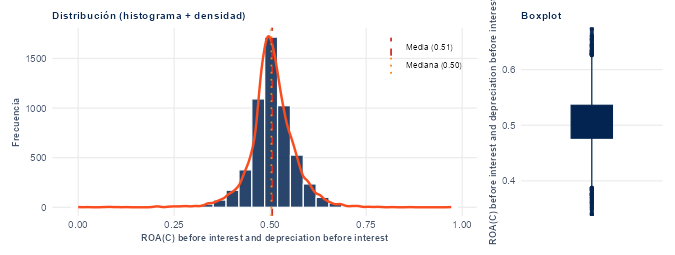

El histograma de **ROA(C) before interest and depreciation before interest** muestra una distribución relativamente simétrica, con una media de **50.53%** y una mediana de **50.32%**. La curtosis observada de **6.48** indica una concentración notable de observaciones alrededor de la zona central, acompañada por la presencia de valores atípicos en las colas. Esta morfología sugiere una alta homogeneidad en el grueso de las empresas analizadas, pero con comportamientos extremos puntuales a monitorear en la etapa de preprocesamiento.

ROA(A) before interest and % after tax

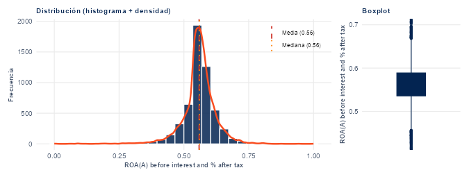

El histograma de **ROA(A) before interest and % after tax** muestra un marcado sesgo a la izquierda (asimetría negativa), con una media de **55.86%** y una mediana de **56.02%**. La curtosis observada de **9.08** indica una concentración notable de observaciones alrededor de la zona central, acompañada por la presencia de valores atípicos en las colas. Esta morfología sugiere una alta homogeneidad en el grueso de las empresas analizadas, pero con comportamientos extremos puntuales a monitorear en la etapa de preprocesamiento.

ROA(B) before interest and depreciation after tax

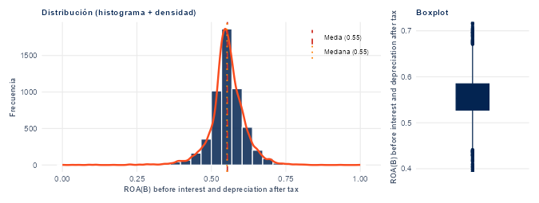

El histograma de **ROA(B) before interest and depreciation after tax** muestra un marcado sesgo a la izquierda (asimetría negativa), con una media de **55.37%** y una mediana de **55.26%**. La curtosis observada de **8.36** indica una concentración notable de observaciones alrededor de la zona central, acompañada por la presencia de valores atípicos en las colas. Esta morfología sugiere una alta homogeneidad en el grueso de las empresas analizadas, pero con comportamientos extremos puntuales a monitorear en la etapa de preprocesamiento.

Operating Gross Margin

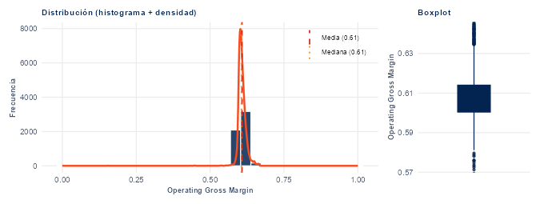

El histograma de **Operating Gross Margin** muestra un marcado sesgo a la izquierda (asimetría negativa), con una media de **60.80%** y una mediana de **60.61%**. La curtosis observada de **377.59** indica una concentración notable de observaciones alrededor de la zona central, acompañada por la presencia de valores atípicos en las colas. Esta morfología sugiere una alta homogeneidad en el grueso de las empresas analizadas, pero con comportamientos extremos puntuales a monitorear en la etapa de preprocesamiento.

Realized Sales Gross Margin

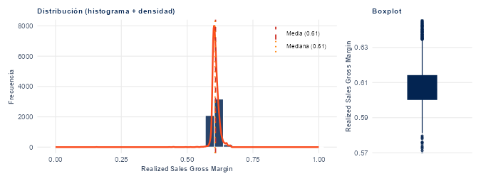

El histograma de **Realized Sales Gross Margin** muestra un marcado sesgo a la izquierda (asimetría negativa), con una media de **60.80%** y una mediana de **60.60%**. La curtosis observada de **378.72** indica una concentración notable de observaciones alrededor de la zona central, acompañada por la presencia de valores atípicos en las colas. Esta morfología sugiere una alta homogeneidad en el grueso de las empresas analizadas, pero con comportamientos extremos puntuales a monitorear en la etapa de preprocesamiento.

Operating Profit Rate

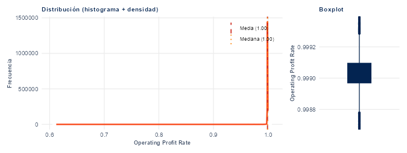

El histograma de **Operating Profit Rate** muestra un marcado sesgo a la izquierda (asimetría negativa), con una media de **99.89%** y una mediana de **99.90%**. La curtosis observada de **5041.16** indica una concentración notable de observaciones alrededor de la zona central, acompañada por la presencia de valores atípicos en las colas. Esta morfología sugiere una alta homogeneidad en el grueso de las empresas analizadas, pero con comportamientos extremos puntuales a monitorear en la etapa de preprocesamiento.

Pre-tax net Interest Rate

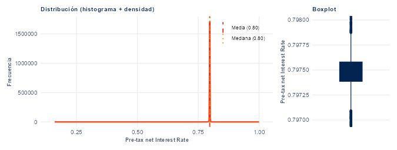

El histograma de **Pre-tax net Interest Rate** muestra un marcado sesgo a la izquierda (asimetría negativa), con una media de **79.73%** y una mediana de **79.75%**. La curtosis observada de **3772.15** indica una concentración notable de observaciones alrededor de la zona central, acompañada por la presencia de valores atípicos en las colas. Esta morfología sugiere una alta homogeneidad en el grueso de las empresas analizadas, pero con comportamientos extremos puntuales a monitorear en la etapa de preprocesamiento.

After-tax net Interest Rate

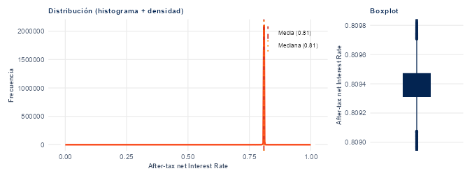

El histograma de **After-tax net Interest Rate** muestra un marcado sesgo a la izquierda (asimetría negativa), con una media de **80.92%** y una mediana de **80.94%**. La curtosis observada de **4356.85** indica una concentración notable de observaciones alrededor de la zona central, acompañada por la presencia de valores atípicos en las colas. Esta morfología sugiere una alta homogeneidad en el grueso de las empresas analizadas, pero con comportamientos extremos puntuales a monitorear en la etapa de preprocesamiento.

Non-industry income and expenditure/revenue

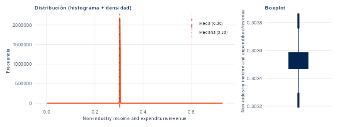

El histograma de **Non-industry income and expenditure/revenue** muestra un marcado sesgo a la derecha (asimetría positiva), con una media de **0.3035 ratio** y una mediana de **0.3035 ratio**. La curtosis observada de **1881.14** indica una concentración notable de observaciones alrededor de la zona central, acompañada por la presencia de valores atípicos en las colas. Esta morfología sugiere una alta homogeneidad en el grueso de las empresas analizadas, pero con comportamientos extremos puntuales a monitorear en la etapa de preprocesamiento.

Continuous interest rate (after tax)

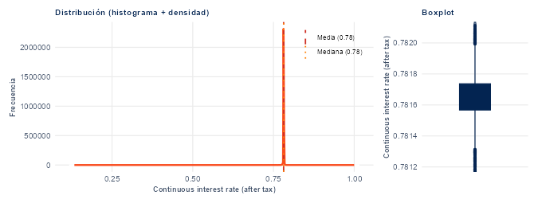

El histograma de **Continuous interest rate (after tax)** muestra un marcado sesgo a la izquierda (asimetría negativa), con una media de **78.15%** y una mediana de **78.16%**. La curtosis observada de **4160.36** indica una concentración notable de observaciones alrededor de la zona central, acompañada por la presencia de valores atípicos en las colas. Esta morfología sugiere una alta homogeneidad en el grueso de las empresas analizadas, pero con comportamientos extremos puntuales a monitorear en la etapa de preprocesamiento.

Operating Expense Rate

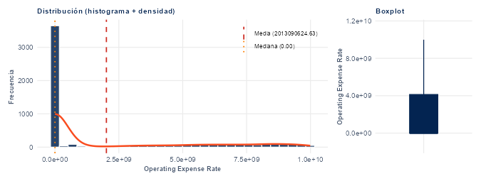

El histograma de **Operating Expense Rate** muestra un marcado sesgo a la derecha (asimetría positiva), con una media de **201309062463.37%** y una mediana de **0.03%**. La curtosis observada de **-0.11** indica una concentración notable de observaciones alrededor de la zona central, acompañada por la presencia de valores atípicos en las colas. Esta morfología sugiere una alta homogeneidad en el grueso de las empresas analizadas, pero con comportamientos extremos puntuales a monitorear en la etapa de preprocesamiento.

Research and development expense rate

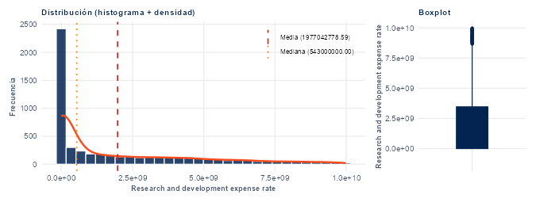

El histograma de **Research and development expense rate** muestra un marcado sesgo a la derecha (asimetría positiva), con una media de **197704277859.25%** y una mediana de **54300000000.00%**. La curtosis observada de **0.55** indica una concentración notable de observaciones alrededor de la zona central, acompañada por la presencia de valores atípicos en las colas. Esta morfología sugiere una alta homogeneidad en el grueso de las empresas analizadas, pero con comportamientos extremos puntuales a monitorear en la etapa de preprocesamiento.

Cash flow rate

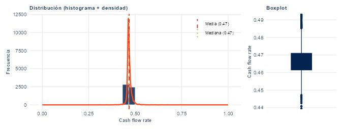

El histograma de **Cash flow rate** muestra un marcado sesgo a la derecha (asimetría positiva), con una media de **46.75%** y una mediana de **46.51%**. La curtosis observada de **262.45** indica una concentración notable de observaciones alrededor de la zona central, acompañada por la presencia de valores atípicos en las colas. Esta morfología sugiere una alta homogeneidad en el grueso de las empresas analizadas, pero con comportamientos extremos puntuales a monitorear en la etapa de preprocesamiento.

Interest-bearing debt interest rate

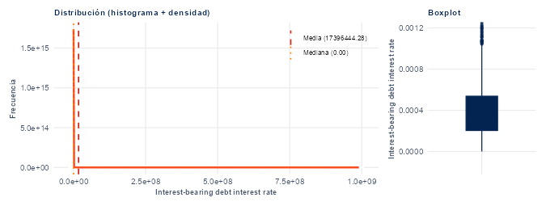

El histograma de **Interest-bearing debt interest rate** muestra un marcado sesgo a la derecha (asimetría positiva), con una media de **1739644428.25%** y una mediana de **0.03%**. La curtosis observada de **47.35** indica una concentración notable de observaciones alrededor de la zona central, acompañada por la presencia de valores atípicos en las colas. Esta morfología sugiere una alta homogeneidad en el grueso de las empresas analizadas, pero con comportamientos extremos puntuales a monitorear en la etapa de preprocesamiento.

Tax rate (A)

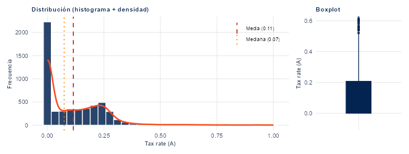

El histograma de **Tax rate (A)** muestra un marcado sesgo a la derecha (asimetría positiva), con una media de **11.50%** y una mediana de **7.42%**. La curtosis observada de **5.87** indica una concentración notable de observaciones alrededor de la zona central, acompañada por la presencia de valores atípicos en las colas. Esta morfología sugiere una alta homogeneidad en el grueso de las empresas analizadas, pero con comportamientos extremos puntuales a monitorear en la etapa de preprocesamiento.

Net Value Per Share (B)

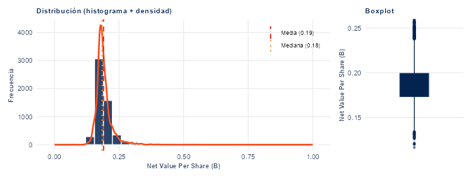

El histograma de **Net Value Per Share (B)** muestra un marcado sesgo a la derecha (asimetría positiva), con una media de **0.1902 Yuan ¥/acción** y una mediana de **0.1842 Yuan ¥/acción**. La curtosis observada de **79.43** indica una concentración notable de observaciones alrededor de la zona central, acompañada por la presencia de valores atípicos en las colas. Esta morfología sugiere una alta homogeneidad en el grueso de las empresas analizadas, pero con comportamientos extremos puntuales a monitorear en la etapa de preprocesamiento.

Net Value Per Share (A)

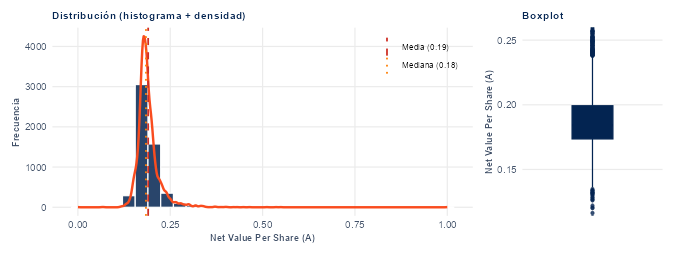

El histograma de **Net Value Per Share (A)** muestra un marcado sesgo a la derecha (asimetría positiva), con una media de **0.1902 Yuan ¥/acción** y una mediana de **0.1842 Yuan ¥/acción**. La curtosis observada de **78.56** indica una concentración notable de observaciones alrededor de la zona central, acompañada por la presencia de valores atípicos en las colas. Esta morfología sugiere una alta homogeneidad en el grueso de las empresas analizadas, pero con comportamientos extremos puntuales a monitorear en la etapa de preprocesamiento.

Net Value Per Share (C)

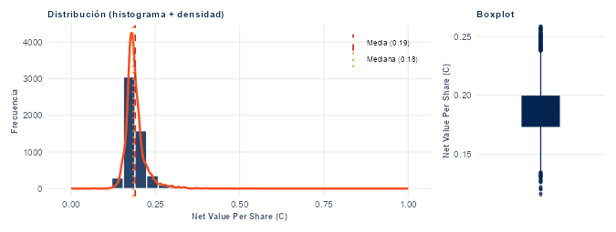

El histograma de **Net Value Per Share (C)** muestra un marcado sesgo a la derecha (asimetría positiva), con una media de **0.1903 Yuan ¥/acción** y una mediana de **0.1843 Yuan ¥/acción**. La curtosis observada de **78.47** indica una concentración notable de observaciones alrededor de la zona central, acompañada por la presencia de valores atípicos en las colas. Esta morfología sugiere una alta homogeneidad en el grueso de las empresas analizadas, pero con comportamientos extremos puntuales a monitorear en la etapa de preprocesamiento.

Persistent EPS in the Last Four Seasons

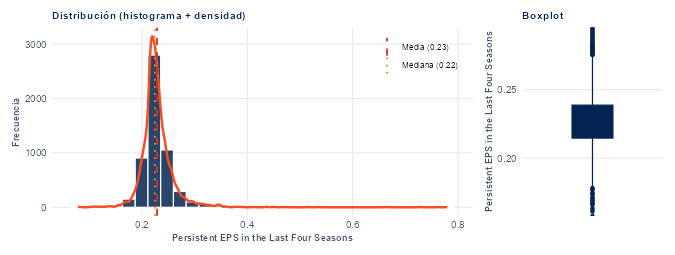

El histograma de **Persistent EPS in the Last Four Seasons** muestra un marcado sesgo a la derecha (asimetría positiva), con una media de **0.2287 Yuan ¥/acción** y una mediana de **0.2246 Yuan ¥/acción**. La curtosis observada de **52.87** indica una concentración notable de observaciones alrededor de la zona central, acompañada por la presencia de valores atípicos en las colas. Esta morfología sugiere una alta homogeneidad en el grueso de las empresas analizadas, pero con comportamientos extremos puntuales a monitorear en la etapa de preprocesamiento.

Cash Flow Per Share

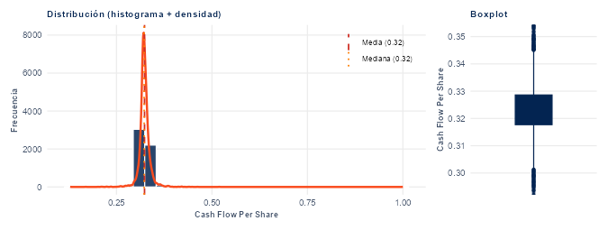

El histograma de **Cash Flow Per Share** muestra un marcado sesgo a la derecha (asimetría positiva), con una media de **0.3235 Yuan ¥/acción** y una mediana de **0.3225 Yuan ¥/acción**. La curtosis observada de **433.50** indica una concentración notable de observaciones alrededor de la zona central, acompañada por la presencia de valores atípicos en las colas. Esta morfología sugiere una alta homogeneidad en el grueso de las empresas analizadas, pero con comportamientos extremos puntuales a monitorear en la etapa de preprocesamiento.

Revenue Per Share (Yuan ¥)

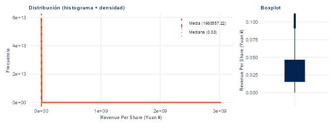

El histograma de **Revenue Per Share (Yuan ¥)** muestra un marcado sesgo a la derecha (asimetría positiva), con una media de **1660557.2236 Yuan ¥/acción** y una mediana de **0.0273 Yuan ¥/acción**. La curtosis observada de **1701.87** indica una concentración notable de observaciones alrededor de la zona central, acompañada por la presencia de valores atípicos en las colas. Esta morfología sugiere una alta homogeneidad en el grueso de las empresas analizadas, pero con comportamientos extremos puntuales a monitorear en la etapa de preprocesamiento.

Operating Profit Per Share (Yuan ¥)

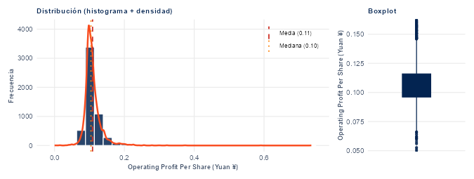

El histograma de **Operating Profit Per Share (Yuan ¥)** muestra un marcado sesgo a la derecha (asimetría positiva), con una media de **0.1089 Yuan ¥/acción** y una mediana de **0.1043 Yuan ¥/acción**. La curtosis observada de **92.73** indica una concentración notable de observaciones alrededor de la zona central, acompañada por la presencia de valores atípicos en las colas. Esta morfología sugiere una alta homogeneidad en el grueso de las empresas analizadas, pero con comportamientos extremos puntuales a monitorear en la etapa de preprocesamiento.

Per Share Net profit before tax (Yuan ¥)

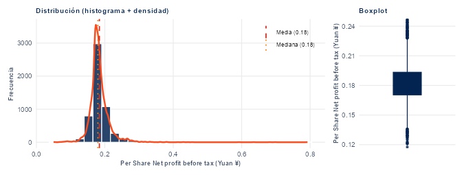

El histograma de **Per Share Net profit before tax (Yuan ¥)** muestra un marcado sesgo a la derecha (asimetría positiva), con una media de **0.1842 Yuan ¥/acción** y una mediana de **0.1798 Yuan ¥/acción**. La curtosis observada de **65.71** indica una concentración notable de observaciones alrededor de la zona central, acompañada por la presencia de valores atípicos en las colas. Esta morfología sugiere una alta homogeneidad en el grueso de las empresas analizadas, pero con comportamientos extremos puntuales a monitorear en la etapa de preprocesamiento.

Realized Sales Gross Profit Growth Rate

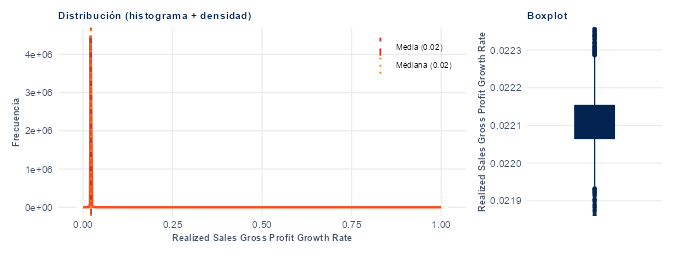

El histograma de **Realized Sales Gross Profit Growth Rate** muestra un marcado sesgo a la derecha (asimetría positiva), con una media de **2.25%** y una mediana de **2.21%**. La curtosis observada de **5053.61** indica una concentración notable de observaciones alrededor de la zona central, acompañada por la presencia de valores atípicos en las colas. Esta morfología sugiere una alta homogeneidad en el grueso de las empresas analizadas, pero con comportamientos extremos puntuales a monitorear en la etapa de preprocesamiento.

Operating Profit Growth Rate

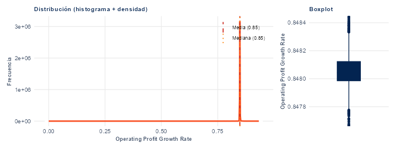

El histograma de **Operating Profit Growth Rate** muestra un marcado sesgo a la izquierda (asimetría negativa), con una media de **84.79%** y una mediana de **84.80%**. La curtosis observada de **4836.49** indica una concentración notable de observaciones alrededor de la zona central, acompañada por la presencia de valores atípicos en las colas. Esta morfología sugiere una alta homogeneidad en el grueso de las empresas analizadas, pero con comportamientos extremos puntuales a monitorear en la etapa de preprocesamiento.